# Food Factors

# Load and Format the Data

```r
library(MASS)
library(plyr)
library(corrplot)
library(RColorBrewer)
suppressWarnings(library(ggplot2))
library(tidyverse)
dat <- read.csv("z_trial_data.csv")[,-1]
dat <- as_tibble(dat)
```

To make the visuals more interpretable, we will flip 4 of the measures. This is to make these four measures become positively related to the other measures.

- Sugar => Low-Sugar
- Disgusting => Not Disgusting
- Healthy => Unhealthy
- Vitamins => Low vitamins

```r
rdat <- dat %>% select(stimulus, choice.rating, starts_with("rating"))

# Rename
colnames(rdat) <- sub("rating[.]", "", colnames(rdat))
colnames(rdat) <- sub("[.]rating", "", colnames(rdat))

# Flip
rdat$sugar <- 10 - rdat$sugar
rdat$disgusting <- 10 - rdat$disgusting
rdat$healthy <- 10 - rdat$healthy
rdat$vitamins <- 10 - rdat$vitamins
## rename
cinds <- sapply(c("sugar", "disgusting", "healthy", "vitamins"), function(x) which(colnames(rdat) == x))
colnames(rdat)[cinds] <- c("low-sugar", "not-disgusting", "unhealthy", "low-vitamins")

# For use with analysis
rmat <- as.matrix(rdat[,-1])
rownames(rmat) <- rdat$stimulus
rmat.nochoice <- rmat[,-1]

# Shows the ratings/choice for each of the food items
head(rmat)
```

```
##                        choice calories carbohydrates not-disgusting familiar
## chickenfingers           7.66    10.00          9.81           9.88    10.00
## orange slices            7.28     0.45          0.10           9.87     9.92
## lollipops                0.04     9.56          8.74           9.98     9.94
## salad w chicken         10.00     4.65          4.83           9.85     9.86
## reesespieces             9.97     9.95          9.99          10.00    10.00
## grilled chicken strips   2.46     3.39          0.59           9.90     9.87
##                         fat feel filling gluten unhealthy othertasty protein
## chickenfingers         9.48 9.99    9.62   9.42      5.49       9.59    9.97
## orange slices          0.18 9.97    4.48   0.04      0.06       8.89    0.54
## lollipops              9.12 7.60    0.48   9.68      9.96       9.67    0.12
## salad w chicken        4.31 9.67    8.23   4.70      0.33       9.02    9.37
## reesespieces           9.94 9.95    8.78   9.94      9.93       9.86    0.05
## grilled chicken strips 0.50 7.42    8.58   0.54      0.30       7.68   10.00
##                        sodium low-sugar sweetsaltysavory tasty texture
## chickenfingers           9.13      2.91             8.59  9.91    9.40
## orange slices            0.04      5.72             1.97  9.92   10.00
## lollipops                7.33      0.13             0.15  9.08    9.97
## salad w chicken          2.60      7.61             6.30  9.94   10.00
## reesespieces             9.49      0.06             0.05 10.00    9.40
## grilled chicken strips   1.21      7.75             7.15  7.80    6.36
##                        low-vitamins
## chickenfingers                 4.17
## orange slices                  0.36
## lollipops                      9.84
## salad w chicken                0.44
## reesespieces                   9.96
## grilled chicken strips         0.57
```

# Correlation Matrix

Get the average of each of the ratings/choice across participants. Then compute and visualize the correlations between each pair of ratings/choice.

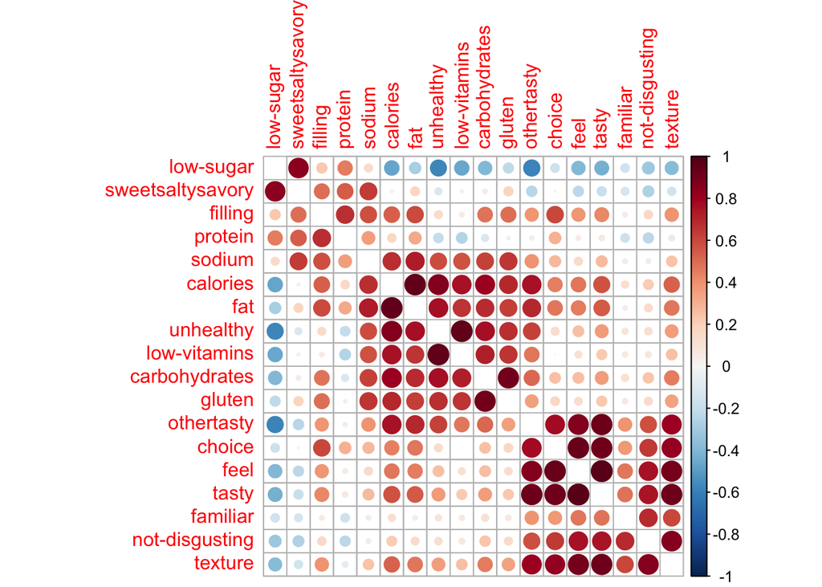

```r
ave.mat <- rdat %>%
  group_by(stimulus) %>%
  summarise_all(mean) %>%
  select(-stimulus)

M <- cor(ave.mat)
diag(M) <- 0

corrplot(M, method="circle", diag = F, order="hclust",
         #is.corr=F, cl.lim=c(-0.85,0.85),
         col=rev(colorRampPalette(brewer.pal(n=11, name="RdBu"))(256)))
```

Manually order based on what we might have expected to see

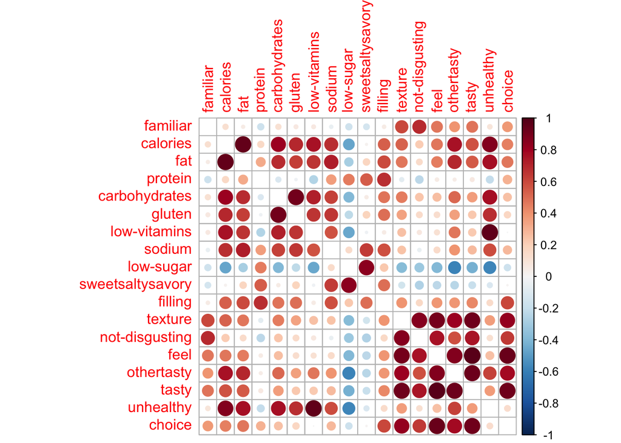

```r
new.ord <- c("familiar", "calories", "fat", "protein", "carbohydrates", "gluten", "low-vitamins", "sodium", "low-sugar", "sweetsaltysavory", "filling", "texture", "not-disgusting", "feel", "othertasty", "tasty", "unhealthy", "choice")

ave.mat2 <- ave.mat[,new.ord]
M <- cor(ave.mat2)
diag(M) <- 0

corrplot(M, method="circle", diag = F, #order="hclust",
         #is.corr=F, cl.lim=c(-0.85,0.85),
         col=rev(colorRampPalette(brewer.pal(n=11, name="RdBu"))(256)))
```

# Factor Analysis

We can see that there is a clear structure in the data above. Here, we try to extract that structure by doing a factor analysis.

For the factor analysis, I will remove the choice data to make it only about the ratings.

Determine the optimal number of factors (it’s 3)

```r
nFactors::nCng(as.data.frame(rmat.nochoice), model="factors")
```

```
## [1] 3
```

```r
cols2 <- colorRampPalette(c("#67001F", "#B2182B", "#D6604D",
                            "#F4A582", "#FDDBC7", "#FFFFFF", "#D1E5F0", "#92C5DE",
                            "#4393C3", "#2166AC", "#053061"))(200)
```

Plot 3 factors and there factor scores. I use hierarchical clustering to order the different ratings and make the plot more interpretable.

```r
fit <- factanal(rmat.nochoice, 3, scores="regression")

d <- dist(fit$loadings)
hc <- hclust(d, method="average")
dend <- as.dendrogram(hc)
loads <- fit$loadings[order.dendrogram(dend),]
loads <- rbind(choice=loads[rownames(loads) == "choice",], loads[rownames(loads) != "choice",])

# Make tasty first, then health, and finally sweet/savory
loads2 <- loads[,c(2,1,3)]
colnames(loads2) <- sprintf("Factor-%i", 1:3)

# Put the sweet/savory to the end
#loads2 <- rbind(loads2[-c(1:4),], loads2[4:1,])
loads2 <- rbind(loads2[-c(1:4),], loads2[1:4,])

# Just for reporting purposes
sort(loads2[,1], decreasing = T)
```

```
##            tasty             feel          texture   not-disgusting
##      0.846875618      0.790179451      0.707855868      0.624244430
##       othertasty         familiar          filling         calories
##      0.569827440      0.410225914      0.252907781      0.192090620
##              fat    carbohydrates          protein           gluten
##      0.139852842      0.108627874      0.030306361      0.023430776
##           sodium        unhealthy     low-vitamins sweetsaltysavory
##      0.002820224     -0.037784035     -0.085749089     -0.164977297
##        low-sugar
##     -0.207308599
```

```r
sort(loads2[,2], decreasing = T)
```

```
##        unhealthy         calories              fat     low-vitamins
##      0.817434241      0.789084190      0.692721288      0.640023667
##    carbohydrates           gluten           sodium       othertasty
##      0.620580381      0.584869218      0.552807991      0.357829143
##          filling            tasty          texture             feel
##      0.240489106      0.113928968      0.072838300      0.052872139
## sweetsaltysavory          protein         familiar   not-disgusting
##      0.021801583     -0.004830449     -0.006380610     -0.054513138
##        low-sugar
##     -0.406076816
```

```r
sort(loads2[,3], decreasing = T)
```

```
##          protein sweetsaltysavory          filling           sodium
##       0.65752760       0.62798522       0.54419853       0.46129602
##        low-sugar              fat           gluten         calories
##       0.43043700       0.28795436       0.15516511       0.14033158
##             feel            tasty    carbohydrates          texture
##       0.09287955       0.07667811       0.04546506       0.03591942
##       othertasty         familiar   not-disgusting        unhealthy
##       0.01817093      -0.07250618      -0.10134941      -0.25273603
##     low-vitamins
##      -0.27643731
```

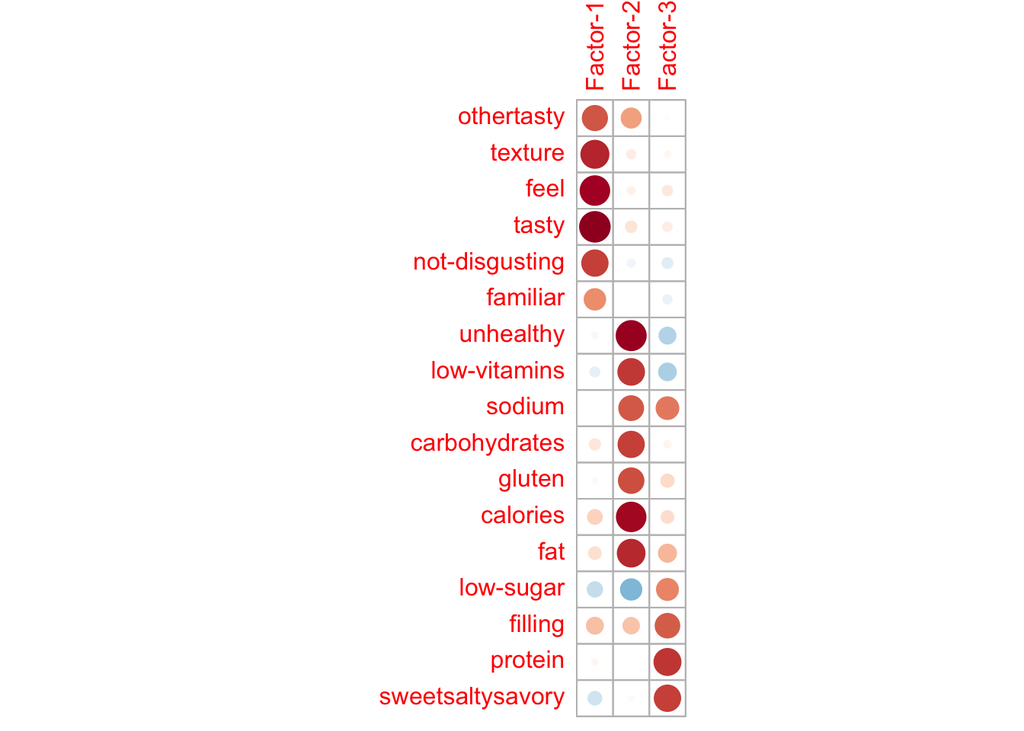

```r
# Plot
corrplot::corrplot(loads2, diag=T, col=rev(cols2), cl.pos="n")
```

Do a different arrangement for the audience.

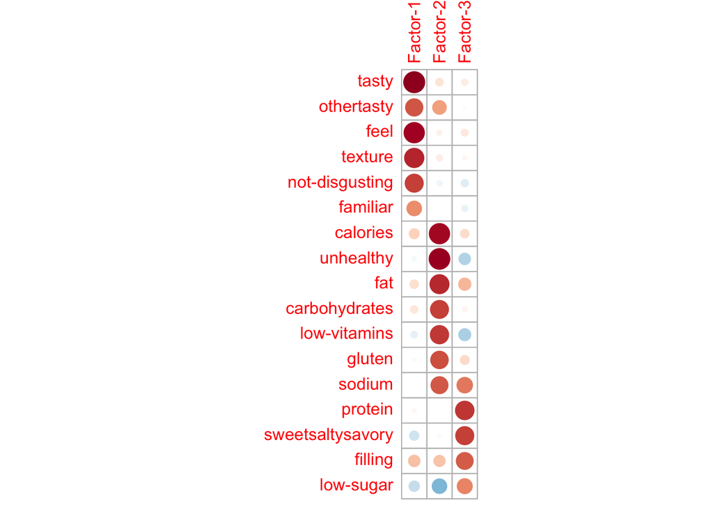

```r
rlabs <- c("tasty", "othertasty", "feel", "texture", "not-disgusting", "familiar",
  "calories", "unhealthy", "fat", "carbohydrates", "low-vitamins", "gluten", "sodium",
  "protein", "sweetsaltysavory", "filling", "low-sugar")

inds <- sapply(rlabs, function(x) which(rownames(loads2)==x))
corrplot::corrplot(loads2[inds,], diag=T, col=rev(cols2), cl.pos="n")
```

Gather the scores and re-label the columns accordingly.

```r
# scores and re-label columns
scores3 <- fit$scores
ind1 <- which.max(fit$loadings[rownames(fit$loadings) == "unhealthy",])
ind2 <- which.max(fit$loadings[rownames(fit$loadings) == "tasty",])
ind3 <- which.max(fit$loadings[rownames(fit$loadings) == "sweetsaltysavory",])
colnames(scores3) <- c("Food.UnHealth", "Food.Taste", "Food.SweetProtein")[c(ind1,ind2,ind3)]
```

Save the data out

```r
head(scores3)
```

```
##                        Food.UnHealth Food.Taste Food.SweetProtein
## chickenfingers             1.0841141  1.2087417         1.6565509
## orange slices             -1.7943950  1.5451714        -0.6272620
## lollipops                  1.6755844  0.8464715        -1.2780739
## salad w chicken           -0.8959373  1.3959697         1.2601445
## reesespieces               1.9168391  1.2518884        -0.5089433
## grilled chicken strips    -1.4268449  0.5992230         1.0402695
```

```r
outdf <- data.frame(subjectId=dat$subjectId, stimulus=dat$stimulus, scores3)
write.csv(outdf, file="z_foodrating_factors.csv")
```